# credit_card_fraud_detection

```python
import os
import time
import torch
import random
import tarfile
import warnings
import subprocess
import numpy as np
import pandas as pd
import torch.nn as nn
import seaborn as sns
from sklearn.svm import SVC
import torch.optim as optim
import torch.nn.functional as F
import matplotlib.pyplot as plt
from collections import Counter
from xgboost import XGBClassifier
from sklearn.model_selection import GridSearchCV
from sklearn.linear_model import LogisticRegression
from sklearn.ensemble import RandomForestClassifier
from sklearn.model_selection import train_test_split
from torch.utils.data import DataLoader, TensorDataset
from sklearn.preprocessing import LabelEncoder, StandardScaler
from sklearn.metrics import classification_report, accuracy_score, precision_score, recall_score, f1_score, confusion_matrix, roc_curve, auc, precision_recall_fscore_support, roc_auc_score
import networkx as nx

# Suppress warnings
warnings.filterwarnings("ignore")
print(torch.__version__)
```

```
2.3.0.post100
```

**Dataset**:

The dataset presents an extensive collection of around 24.4 million credit card transactions, sourced from IBM's financial database. Capturing a wide spectrum of user interactions, the data provides a detailed snapshot of transaction behaviors, patterns, and potential vulnerabilities. Details include: User&card info, time&amount of transactions, merchant details, fraud detection flag.

**Methodology**:

- **Exploratory Data Analysis (EDA):** Analyze trends, gain insights into fraudulant transaction behaviors and system vulnerabilities.
- **Predictive Modelling:** Develop models based on past fraudulent transactions to predict and mitigate future fraud, aiming to enhance overall security and user trust.

### Load Data

```python
## Download data

# Step 1: Define the URL and output file names
url = "https://public.boxcloud.com/d/1/b1!Zg-Uic8A7f7OK0nIZJiMELe1vOYJZXCJKK_xl9RGlMlbAFSV5e3jmKDP1VIM6ao2eIQU2U3dNypa7R0C9shiHuv3tu09AhNA4HG6gBHIeGd7gHhuqUHysBJsWq4M1baWBp_MwJSH3xCxyZxpDAq-nI5ENRuLPEb27KZCQlSOIQQxwAhhWmwNwuJeXnofV9wzAhZfytszcjXJ7hqpmVC-4uL8MY_yRtxlBzDDH--aEIErEAPnYNwuNqWQXAtauiBRLoNlMMpaggZ2vr2NMt3P-GgNlEVvjOx6Ja7bbHqaLgN_msPt15O886BUr9r0lIdhU3RrWec9vzUeetyUjdXe8nO-JIYQd7tUb-PWFgq0kPaL4jeI_D2L4pNTq4z7ko4Tycpsw-UQt4XUTmKZymBdFPFyGFJCA3Q9M9mq6OEstkMt8d9L-yGRwumvCPx2sM0uxDLOy7boO5xRYbE-aqLMvL0B_MH6-LjqejrcA_BD6QXlxqKajMxjw0XDxtSlbC1E6OnpcnFE9HQpNj7Bc1zGt2KXAbErbSntEgbb0VU-pDCZ2SbfVjZa5RCLDJHot-qIm2dgMZisvS_1hm8n_XvK7Hvpl1oXPjLatKuW2bGky1WSoUblBiSHBi8guLwk0BDk4ocySQXR3EepON4BW6KSrEp-Vhf_b3j0M3DScAK2pA-igfoyhKqNWSsFd1bvSDJDersUb5fD4G9M8mdRlT2upNtvj_0KYW0qmMww7Tg2jWiI-yuaZ1K4H03N9_BguZhj7kxROzbUBjE1WAlrtWFbV_wKRnDVDk38b7_t2KxZleicLAnx70TvGKO83diWYySlhX_n6EfQW3oQaZj6QctydOdJRlrnsUxyHsOHkpjPLt6IKGMYNNcjYzawizzSBXw_SAtuRLoWIonplSMhLv2VkbFfqZu4dg1qNohTv4TqMT7cvBzevEyJfPxfJRtc9tx4FFZekY4eai9tf9HiaUaXieR96p3DvalAFevhqEE4yUr6f3fi6dE5_lRYhNvLd2vRt1exLP8FGW6KN_V_iGYK1bp3aBb_J71qdbKAaWivZYih1uTMQrBeEPJg6_3mFeDxdLA6EKxLppKV9LhXoYmObFulwHY8vWreTLUZXghRKeW2vMz-W1nGZy7ev6fFN-hkdBpb3LMY8nqqAn5m44mLfjvzvOcZtKLJBp1jqvHE7Sg6oah2uiqd6zp2pdsukjQ9ixU3dH0SxHR5kp84P2O7Hs-YLgOAVipNz1c-095FmeNTdj2nUo5iNDIZh9W_rh4agzgtEmU9uETGzOop7-NjsW_GO6FC4jQS0IqtNqoQmnNy8B5Lr2dfiYFwMPCjCA../download"
output_file = "data.tgz"

# Step 2: Download the file using curl
try:
    # Use curl to download the file
    subprocess.run(["curl", "-L", url, "-o", output_file], check=True)
    print(f"File downloaded successfully as {output_file}")
except subprocess.CalledProcessError as e:
    print(f"Error occurred while downloading: {e}")
    exit(1)

# Step 3: Extract the .tgz file
extracted_folder = "extracted_data"
os.makedirs(extracted_folder, exist_ok=True)

try:
    # Open and extract the tgz file
    with tarfile.open(output_file, "r:gz") as tar:
        tar.extractall(path=extracted_folder)
    print(f"File extracted successfully to {extracted_folder}")
except tarfile.TarError as e:
    print(f"Error occurred while extracting the file: {e}")
```

```
  % Total    % Received % Xferd  Average Speed   Time    Time     Time  Current
                                 Dload  Upload   Total   Spent    Left  Speed
  0     0    0     0    0     0      0      0 --:--:-- --:--:-- --:--:--     0
```

```
File downloaded successfully as data.tgz
Error occurred while extracting the file: not a gzip file
```

```
100  1636  100  1636    0     0   1341      0  0:00:01  0:00:01 --:--:--  1342
```

```python
df = pd.read_csv("card_transaction.v1.csv")
```

```python
df.shape
```

```
(24386900, 15)
```

```python
df.columns
```

```
Index(['User', 'Card', 'Year', 'Month', 'Day', 'Time', 'Amount', 'Use Chip',
       'Merchant Name', 'Merchant City', 'Merchant State', 'Zip', 'MCC',
       'Errors?', 'Is Fraud?'],
      dtype='object')
```

```python
df.info()
```

```
<class 'pandas.core.frame.DataFrame'>
RangeIndex: 24386900 entries, 0 to 24386899
Data columns (total 15 columns):
 #   Column          Dtype
---  ------          -----
 0   User            int64
 1   Card            int64
 2   Year            int64
 3   Month           int64
 4   Day             int64
 5   Time            object
 6   Amount          object
 7   Use Chip        object
 8   Merchant Name   int64
 9   Merchant City   object
 10  Merchant State  object
 11  Zip             float64
 12  MCC             int64
 13  Errors?         object
 14  Is Fraud?       object
dtypes: float64(1), int64(7), object(7)
memory usage: 2.7+ GB
```

### Data Cleaning

```python
# We need to make sure that the samples we extracted have some rows where fraud is True
df [df['Is Fraud?'] == 'Yes'].shape
```

```
(29757, 15)
```

[output not shown]

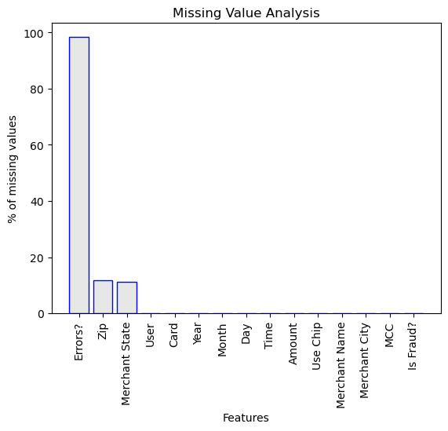

```python
percent_missing=(df.isnull().sum()*100/df.shape[0]).sort_values(ascending=True)
plt.title("Missing Value Analysis")
plt.xlabel("Features")
plt.ylabel("% of missing values")
plt.bar(percent_missing.sort_values(ascending=False).index,percent_missing.sort_values(ascending=False),color=(0.1, 0.1, 0.1, 0.1),edgecolor='blue')
plt.xticks(rotation=90)
```

The `card_id` represents a single card associated with one user. Since a single user can possess multiple cards, each card will have its own unique `card_id` in this context. To address this, we will create a new column by concatenating the `User` and `Card` columns, providing a combined identifier for analysis.

```python
df["card_id"] = df["User"].astype(str) + "_" + df["Card"].astype(str)
```

```python
df.Amount.head(5)
```

```
0    $134.09
1     $38.48
2    $120.34
3    $128.95
4    $104.71
Name: Amount, dtype: object
```

```python
# We need to strip the ‘$’ from the Amount to cast as a float
df["Amount"]=df["Amount"].str.replace("$","").astype(float)
```

```python
# time can't be casted to int so so opted to extract the hour and minute
df["Hour"] = df["Time"].str [0:2]
df["Minute"] = df["Time"].str [3:5]
```

```python
# change the is fraud column to binary
df["Is Fraud?"] = df["Is Fraud?"].apply(lambda x: 1 if x == 'Yes' else 0)
```

### EDA

To derive meaningful insights into fraud cases, we isolate this subset of data for Exploratory Data Analysis (EDA). This focused approach enables a deeper examination and understanding of the patterns and behaviors associated with fraudulent activity.

```python
fraud_data = df[df['Is Fraud?'] == 1]
```

#### Transaction Amount

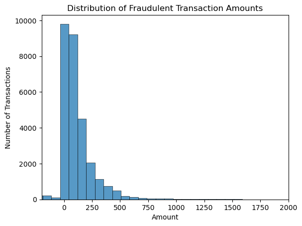

```python
sns.histplot(fraud_data['Amount'].astype(float), kde=False, bins=80)
plt.title('Distribution of Fraudulent Transaction Amounts')
plt.xlabel('Amount')
plt.ylabel('Number of Transactions')
plt.xlim(-200, 2000)
plt.show()
```

The majority of fraudulent transactions fall within the amount range of 0 to 250, highlighting a tendency for fraud to occur more frequently in lower-value transactions.

#### Geographical Distribution

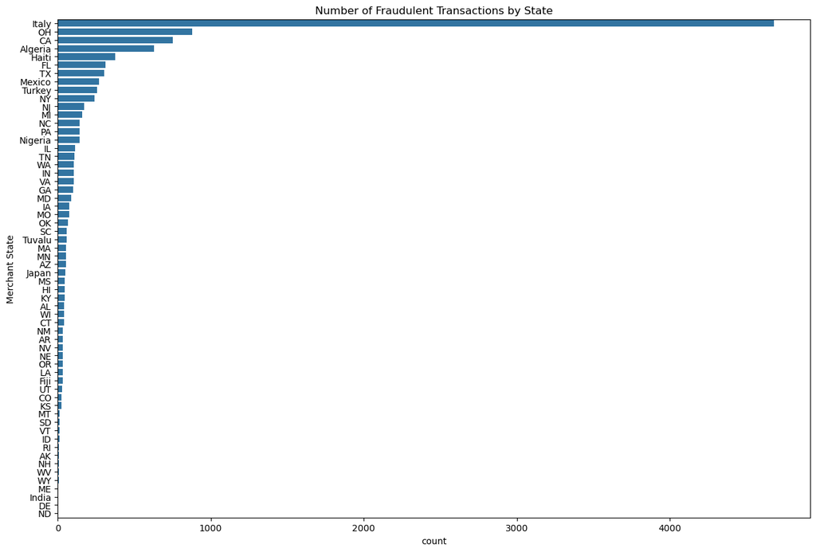

```python
plt.figure(figsize=(15, 10))
sns.countplot(data=fraud_data, y='Merchant State', order=fraud_data['Merchant State'].value_counts().index)
plt.title('Number of Fraudulent Transactions by State')
plt.show()
```

The `State` column includes a mix of U.S. states and other countries, revealing distinct geographical patterns:

- **At the country level**: Italy, Algeria, Haiti, and Mexico emerge as significant hotspots for fraudulent activities.
- **Among U.S. states**: Ohio, California, and Florida report the highest incidences of fraud.

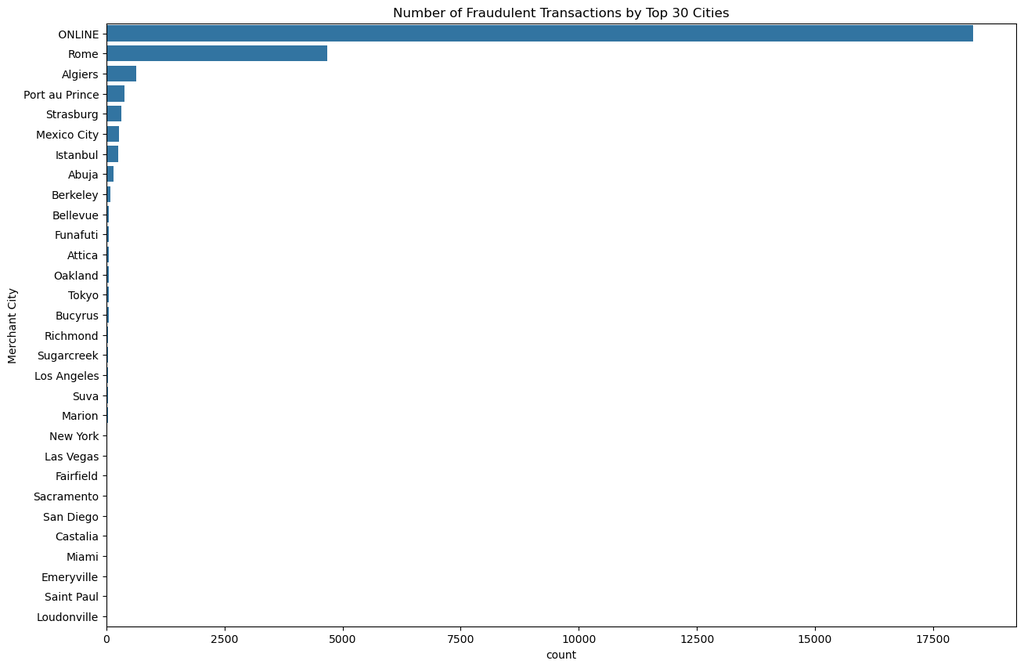

```python
plt.figure(figsize=(15, 10))
top_cities = fraud_data['Merchant City'].value_counts().head(30).index
sns.countplot(data=fraud_data, y='Merchant City', order=top_cities)
plt.title('Number of Fraudulent Transactions by Top 30 Cities')
plt.show()
```

Online transactions serve as the primary platforms where fraud is most prevalent. In addition, cities like Rome, Algiers, and Port-au-Prince stand out as key hotspots, experiencing a high frequency of fraudulent activities.

#### Time Variation

##### By year

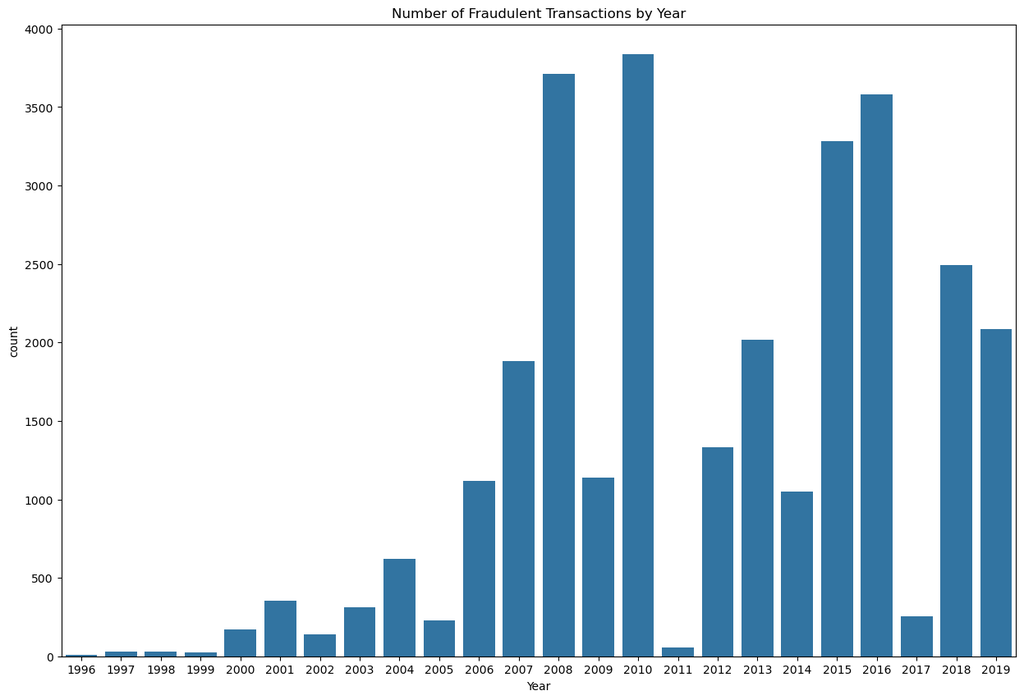

```python
plt.figure(figsize=(15, 10))
sns.countplot(data=fraud_data, x='Year')
plt.title('Number of Fraudulent Transactions by Year')
plt.show()
```

##### By month

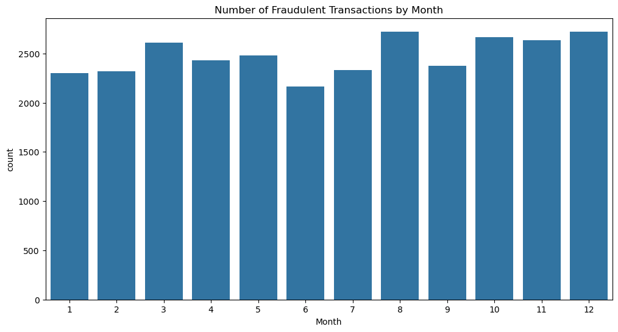

```python
plt.figure(figsize=(12, 6))
sns.countplot(data=fraud_data, x='Month')
plt.title('Number of Fraudulent Transactions by Month')
plt.show()
```

The distribution of fraud cases across months shows minimal variation, though there is a slight increase in fraudulent activities towards the end of the year.

##### By day of month

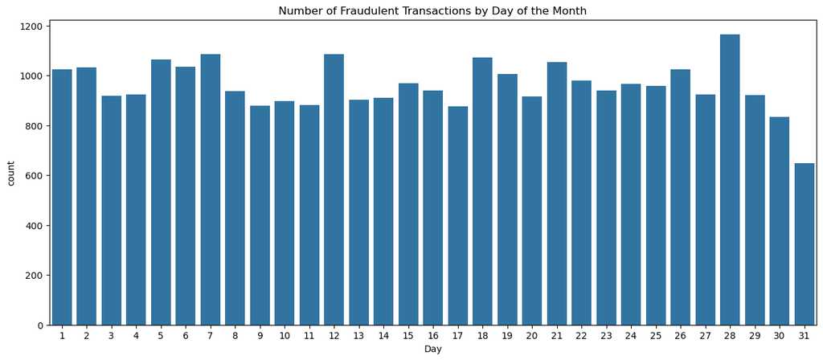

```python
plt.figure(figsize=(15, 6))
sns.countplot(data=fraud_data, x='Day')
plt.title('Number of Fraudulent Transactions by Day of the Month')
plt.show()
```

##### By day of week

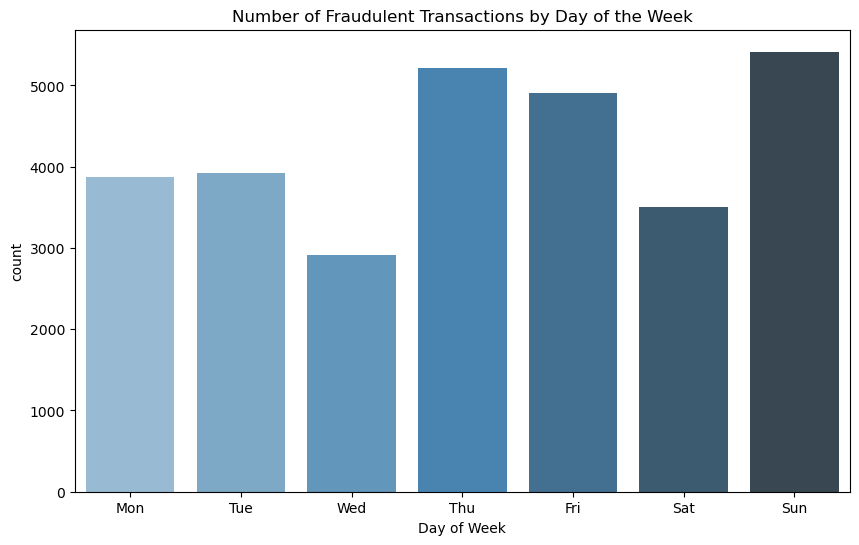

```python
df['Date'] = pd.to_datetime(df[['Year', 'Month', 'Day']])

# Extract day of the week and map it to its name
days = {0:'Mon', 1:'Tue', 2:'Wed', 3:'Thu', 4:'Fri', 5:'Sat', 6:'Sun'}
df['Day of Week'] = df['Date'].dt.dayofweek.map(days)

fraud_data = df[df['Is Fraud?'] == 1]

# Visualize
plt.figure(figsize=(10, 6))
sns.countplot(data=fraud_data, x='Day of Week', order=['Mon', 'Tue', 'Wed', 'Thu', 'Fri', 'Sat', 'Sun'], palette="Blues_d")
plt.title('Number of Fraudulent Transactions by Day of the Week')
plt.show()
```

A higher number of fraud activities occur on Sundays.

##### By hour of day

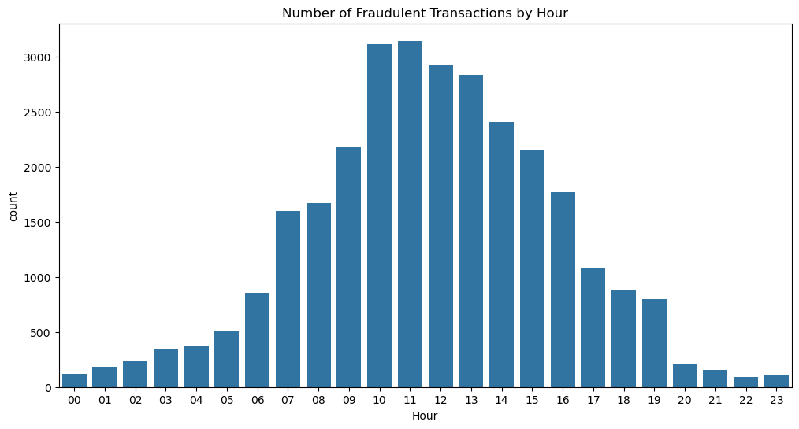

```python
plt.figure(figsize=(12, 6))
sns.countplot(data=fraud_data, x='Hour', order=sorted(fraud_data['Hour'].unique()))
plt.title('Number of Fraudulent Transactions by Hour')
plt.show()
```

Fraud activities predominantly occur between 10 and 11 a.m. local time.

#### Transaction Method

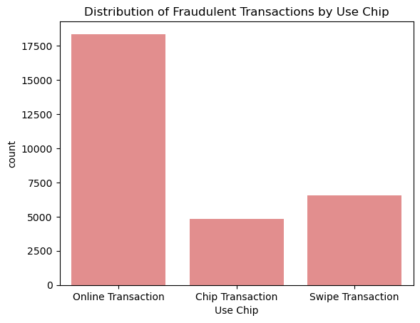

```python
sns.countplot(data=fraud_data, x='Use Chip', color='lightcoral')
plt.title('Distribution of Fraudulent Transactions by Use Chip')
plt.show()
```

Online transactions present the most significant vulnerability to fraud.

### Preprocessing

```python
df = df.drop(["Time","User","Card"],axis=1)
df.info()
```

```
<class 'pandas.core.frame.DataFrame'>
RangeIndex: 24386900 entries, 0 to 24386899
Data columns (total 17 columns):
 #   Column          Dtype
---  ------          -----
 0   Year            int64
 1   Month           int64
 2   Day             int64
 3   Amount          float64
 4   Use Chip        object
 5   Merchant Name   int64
 6   Merchant City   object
 7   Merchant State  object
 8   Zip             float64
 9   MCC             int64
 10  Errors?         object
 11  Is Fraud?       int64
 12  card_id         object
 13  Hour            object
 14  Minute          object
 15  Date            datetime64[ns]
 16  Day of Week     object
dtypes: datetime64[ns](1), float64(2), int64(6), object(8)
memory usage: 3.1+ GB
```

```python
df["Errors?"].unique()
```

```
array([nan, 'Technical Glitch,', 'Insufficient Balance,', 'Bad PIN,',
       'Bad PIN,Insufficient Balance,', 'Bad Expiration,',
       'Bad PIN,Technical Glitch,', 'Bad Card Number,', 'Bad CVV,',
       'Bad Zipcode,', 'Insufficient Balance,Technical Glitch,',
       'Bad Card Number,Insufficient Balance,',
       'Bad Card Number,Bad CVV,', 'Bad CVV,Insufficient Balance,',
       'Bad Card Number,Bad Expiration,', 'Bad Expiration,Bad CVV,',
       'Bad Expiration,Insufficient Balance,',
       'Bad Expiration,Technical Glitch,',
       'Bad Card Number,Bad Expiration,Technical Glitch,',
       'Bad CVV,Technical Glitch,', 'Bad Card Number,Technical Glitch,',
       'Bad Zipcode,Insufficient Balance,',
       'Bad Zipcode,Technical Glitch,',
       'Bad Card Number,Bad Expiration,Insufficient Balance,'],
      dtype=object)
```

```python
df["Errors?"]= df["Errors?"].fillna("No error")
```

The `Zip` and `Merchant State` columns contain missing values, which could impact the accuracy of our graph. Since this information can be derived from the `Merchant City` column, we will drop these two columns to streamline the data.

```python
df = df.drop(columns=["Merchant State","Zip","Date"],axis=1)
```

```python
df["Merchant City"]=LabelEncoder().fit_transform(df["Merchant City"])
df["Use Chip"]=LabelEncoder().fit_transform(df["Use Chip"])
df["Day of Week"]=LabelEncoder().fit_transform(df["Day of Week"])
df["Errors?"]=LabelEncoder().fit_transform(df["Errors?"])
df["Hour"] = df["Hour"].astype(int)
df["Minute"] = df["Minute"].astype(int)
```

```python
df["Errors?"].unique()
```

```
array([22, 23, 20, 14, 15, 10, 16,  3,  0, 17, 21,  8,  4,  1,  5, 11, 12,
       13,  7,  2,  9, 18, 19,  6])
```

```python
df.info()
```

```
<class 'pandas.core.frame.DataFrame'>
RangeIndex: 24386900 entries, 0 to 24386899
Data columns (total 14 columns):
 #   Column         Dtype
---  ------         -----
 0   Year           int64
 1   Month          int64
 2   Day            int64
 3   Amount         float64
 4   Use Chip       int64
 5   Merchant Name  int64
 6   Merchant City  int64
 7   MCC            int64
 8   Errors?        int64
 9   Is Fraud?      int64
 10  card_id        object
 11  Hour           int64
 12  Minute         int64
 13  Day of Week    int64
dtypes: float64(1), int64(12), object(1)
memory usage: 2.5+ GB
```

```python
# Find columns with null values
null_columns = df.columns[df.isnull().any()]

print("Columns containing null values:")
print(null_columns)

null_counts = df[null_columns].isnull().sum()
print("\nCount of null values in each column:")
print(null_counts)
```

```
Columns containing null values:
Index([], dtype='object')

Count of null values in each column:
Series([], dtype: float64)
```

```python
df.head()
```

|  | Year | Month | Day | Amount | Use Chip | Merchant Name | Merchant City | MCC | Errors? | Is Fraud? | card_id | Hour | Minute | Day of Week |
| --- | --- | --- | --- | --- | --- | --- | --- | --- | --- | --- | --- | --- | --- | --- |
| 0 | 2002 | 9 | 1 | 134.09 | 2 | 3527213246127876953 | 6275 | 5300 | 22 | 0 | 0_0 | 6 | 21 | 3 |
| 1 | 2002 | 9 | 1 | 38.48 | 2 | -727612092139916043 | 7828 | 5411 | 22 | 0 | 0_0 | 6 | 42 | 3 |
| 2 | 2002 | 9 | 2 | 120.34 | 2 | -727612092139916043 | 7828 | 5411 | 22 | 0 | 0_0 | 6 | 22 | 1 |
| 3 | 2002 | 9 | 2 | 128.95 | 2 | 3414527459579106770 | 7828 | 5651 | 22 | 0 | 0_0 | 17 | 45 | 1 |
| 4 | 2002 | 9 | 3 | 104.71 | 2 | 5817218446178736267 | 6275 | 5912 | 22 | 0 | 0_0 | 6 | 23 | 5 |

### Fraud Detection with Machine Learning

```python
results={}
# columns_to_select = ['Year', 'Month', 'Day', 'Day of Week', 'Hour', 'Amount', 'Use Chip', 'Merchant Name', 'MCC', 'Is Fraud?']
# df = df[columns_to_select]
```

#### Check Class Balance

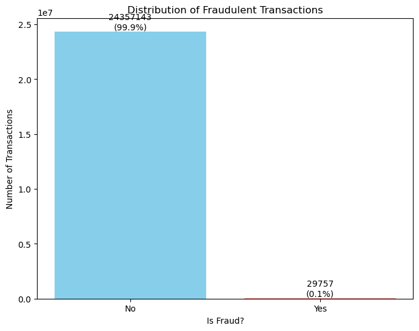

```python
# Assuming 'df' is your DataFrame from the previous code
fraud_counts = df['Is Fraud?'].value_counts()

# Calculate percentages
total_transactions = len(df)
fraud_percentages = (fraud_counts / total_transactions) * 100


plt.figure(figsize=(8, 6))
bars = plt.bar(fraud_counts.index, fraud_counts.values, color=['skyblue', 'lightcoral'])

# Add labels above the bars
for bar, percentage in zip(bars, fraud_percentages):
    yval = bar.get_height()
    plt.text(bar.get_x() + bar.get_width()/2, yval + 10000, f'{int(yval)}\n({percentage:.1f}%)', ha='center', va='bottom')

plt.xlabel('Is Fraud?')
plt.ylabel('Number of Transactions')
plt.title('Distribution of Fraudulent Transactions')
plt.xticks(fraud_counts.index, ['No', 'Yes'])  # Set x-axis tick labels
plt.show()
```

From the above chart we see that our data lacks sufficient positive fraud cases (i.e. `Is Fraud` = 1) for our model to effectively learn to classify transactions. This signals that we may need to class balancing the dataset.

Generally in this case undersampling would be recommended as we have a large dataset [24 mn] of which only 0.1% are fraudulent.

Since we are using RF this may be a moot point but we will test various scenerios to establish the best model

```python
rf = df.copy()
```

```python
rf.info()
del df
```

```
<class 'pandas.core.frame.DataFrame'>
RangeIndex: 24386900 entries, 0 to 24386899
Data columns (total 14 columns):
 #   Column         Dtype
---  ------         -----
 0   Year           int64
 1   Month          int64
 2   Day            int64
 3   Amount         float64
 4   Use Chip       int64
 5   Merchant Name  int64
 6   Merchant City  int64
 7   MCC            int64
 8   Errors?        int64
 9   Is Fraud?      int64
 10  card_id        object
 11  Hour           int64
 12  Minute         int64
 13  Day of Week    int64
dtypes: float64(1), int64(12), object(1)
memory usage: 2.5+ GB
```

```python
# Calculate the number of fraud transactions
fraud_sample = rf[rf['Is Fraud?'] == 1]

# Calculate the number of non-fraud transactions to fill the remaining sample
sample_size = 100000  # desired sample size
non_fraud_sample_size = sample_size - len(fraud_sample)

# Sample from non-fraudulent transactions
non_fraud_sample = rf[rf['Is Fraud?'] == 0].sample(n=non_fraud_sample_size, random_state=42)

# Combine all fraudulent transactions with the sampled non-fraudulent transactions
sampled_rf = pd.concat([fraud_sample, non_fraud_sample])

# Shuffle the sampled DataFrame
sampled_rf = sampled_rf.sample(frac=1, random_state=42).reset_index(drop=True)

# Print the shape of the resulting sampled DataFrame
print(sampled_rf.shape)
del rf
```

```
(100000, 14)
```

[output not shown]

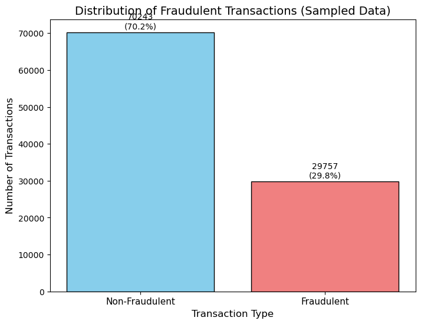

```python
# Count the occurrences of 'Is Fraud?' values
fraud_counts = sampled_rf['Is Fraud?'].value_counts()

# Calculate percentages
total_transactions = len(sampled_rf)
fraud_percentages = (fraud_counts / total_transactions) * 100

# Create the bar plot
plt.figure(figsize=(8, 6))
bars = plt.bar(
    fraud_counts.index,
    fraud_counts.values,
    color=['skyblue', 'lightcoral'],
    edgecolor='black'
)

# Add labels above the bars with counts and percentages
for bar, percentage in zip(bars, fraud_percentages):
    yval = bar.get_height()
    plt.text(
        bar.get_x() + bar.get_width() / 2,
        yval + 500,
        f'{int(yval)}\n({percentage:.1f}%)',
        ha='center',
        va='bottom',
        fontsize=10
    )

# Add axis labels and title
plt.xlabel('Transaction Type', fontsize=12)
plt.ylabel('Number of Transactions', fontsize=12)
plt.title('Distribution of Fraudulent Transactions (Sampled Data)', fontsize=14)

# Customize x-axis tick labels
plt.xticks(fraud_counts.index, ['Non-Fraudulent', 'Fraudulent'], fontsize=11)
```

### Logistic Regression

```
Best parameters: {'C': 0.1, 'max_iter': 100, 'penalty': 'l1', 'solver': 'liblinear'}

Metrics:
Accuracy: 0.69
Precision: 0.48
Recall: 0.70
F1 Score: 0.57

Classification Report:
              precision    recall  f1-score   support

           0       0.84      0.69      0.76     21170
           1       0.48      0.70      0.57      8830

    accuracy                           0.69     30000
   macro avg       0.66      0.69      0.67     30000
weighted avg       0.74      0.69      0.70     30000
```

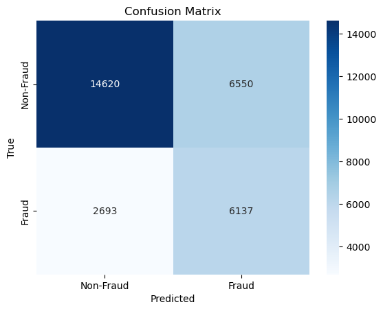

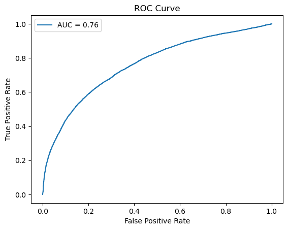

```python
results["Experiment1"] = {}
results["Experiment1"]["Model"] = "Logistic Regression"

# Start time
start_time = time.time()

# Split dataset into features and target
X = sampled_rf.drop(columns=['Is Fraud?'])
y = sampled_rf['Is Fraud?']

# Train-test split
X_train, X_test, y_train, y_test = train_test_split(X, y, test_size=0.3, random_state=42)


# Scale features
sc = StandardScaler()
X_train = sc.fit_transform(X_train)
X_test = sc.transform(X_test)

# Define the parameter grid for Logistic Regression
param_grid = {
    'penalty': ['l1', 'l2', 'elasticnet'],  # Regularization type
    'C': [0.01, 0.1, 1, 10, 100],                  # Regularization strength
    'solver': ['lbfgs', 'liblinear', 'saga'],      # Optimization algorithms
    'max_iter': [100, 200, 500]                    # Maximum iterations
}

# Initialize the Logistic Regression model
log_reg = LogisticRegression(random_state=42, class_weight='balanced')

# Initialize GridSearchCV
grid_search_lr = GridSearchCV(
    estimator=log_reg,
    param_grid=param_grid,
    scoring='f1',         # Optimize for F1 score since fraud detection prioritizes balanced precision and recall
    cv=3,                 # 3-fold cross-validation
    verbose=0,
    n_jobs=-1             # Use all available cores
)

# Fit the GridSearchCV on training data
grid_search_lr.fit(X_train, y_train)

# Best parameters
print("Best parameters:", grid_search_lr.best_params_)

# Best Logistic Regression model
best_lr_model = grid_search_lr.best_estimator_

# Evaluate on the test set
y_pred_lr = best_lr_model.predict(X_test)
y_proba_lr = best_lr_model.predict_proba(X_test)[:, 1]  # Probabilities for ROC

# Metrics Calculation
accuracy = accuracy_score(y_test, y_pred_lr)
precision = precision_score(y_test, y_pred_lr, average='binary', pos_label=1)
recall = recall_score(y_test, y_pred_lr, average='binary', pos_label=1)
f1 = f1_score(y_test, y_pred_lr, average='binary', pos_label=1)

# Print metrics
print("\nMetrics:")
print(f'Accuracy: {accuracy:.2f}')
print(f'Precision: {precision:.2f}')
print(f'Recall: {recall:.2f}')
print(f'F1 Score: {f1:.2f}')

# Print classification report
print("\nClassification Report:")
print(classification_report(y_test, y_pred_lr))

cm = confusion_matrix(y_test, y_pred_lr)
sns.heatmap(
    cm,
    annot=True,
    cmap='Blues',
    fmt='g',
    xticklabels=['Non-Fraud', 'Fraud'],
    yticklabels=['Non-Fraud', 'Fraud']
)
plt.xlabel('Predicted')
plt.ylabel('True')
plt.title('Confusion Matrix')
plt.show()

# ROC Curve
fpr, tpr, _ = roc_curve(y_test, y_proba_lr)
plt.plot(fpr, tpr, label=f'AUC = {auc(fpr, tpr):.2f}')
plt.xlabel('False Positive Rate')
plt.ylabel('True Positive Rate')
plt.title('ROC Curve')
plt.legend()
plt.show()

# End time
end_time = time.time()
# Calculate and print the time taken
elapsed_time = end_time - start_time

results["Experiment1"]["Train Time"] = str(round(elapsed_time, 2)) + ' seconds'
results["Experiment1"]["Accuracy"] = accuracy
results["Experiment1"]["Precision"] = precision
results["Experiment1"]["Recall"] = recall
results["Experiment1"]["F1-Score"] = f1
results["Experiment1"]["Best Parameters"] = str(grid_search_lr.best_params_)
```

### SVM

```python
results["Experiment2"] = {}
results["Experiment2"]["Model"] = "Support Vector Machine"

# Start time
start_time = time.time()

# Split the data
X = sampled_rf.drop(columns=['Is Fraud?'])
y = sampled_rf['Is Fraud?']

X_train, X_test, y_train, y_test = train_test_split(X, y, test_size=0.3, random_state=42)

# Standardize the features
scaler = StandardScaler()
X_train_scaled = scaler.fit_transform(X_train)
X_test_scaled = scaler.transform(X_test)

param_grid = {
    'C': [0.1, 1],       # Test a wide range of values
    'gamma': [0.01, 0.1],  # Similar for gamma
    'kernel': ['rbf']     # Experiment with RBF and polynomial kernels
}

grid_search = GridSearchCV(SVC(probability=True, random_state=42), param_grid, cv=3, scoring='f1', verbose=0, n_jobs=-1)
grid_search.fit(X_train_scaled, y_train)

print("Best parameters:", grid_search.best_params_)
```

```
Best parameters: {'C': 1, 'gamma': 0.1, 'kernel': 'rbf'}
```

```
Metrics
Accuracy: 0.86
Precision: 0.73
Recall: 0.82
F1 Score: 0.77

Classification Report:
              precision    recall  f1-score   support

           0       0.92      0.88      0.90     21170
           1       0.73      0.82      0.77      8830

    accuracy                           0.86     30000
   macro avg       0.83      0.85      0.84     30000
weighted avg       0.87      0.86      0.86     30000
```

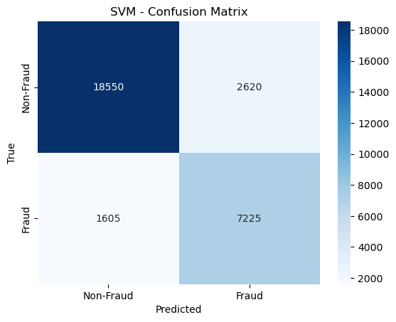

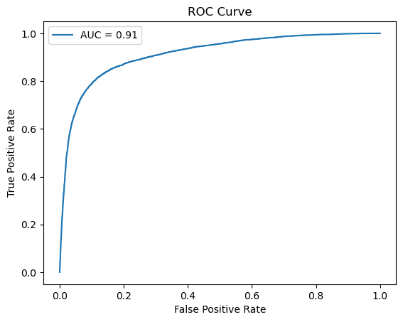

```python
# Train the SVM model
svm_model = SVC(kernel='rbf', class_weight='balanced', gamma=0.1, C=1, probability=True, random_state=42)  # Using RBF kernel
svm_model.fit(X_train_scaled, y_train)

# Predict on the test set
y_pred_svm = svm_model.predict(X_test_scaled)
y_proba_svm = svm_model.predict_proba(X_test_scaled)[:, 1]  # Probabilities for ROC

# Evaluation Metrics
accuracy = accuracy_score(y_test, y_pred_svm)
precision = precision_score(y_test, y_pred_svm, average='binary', pos_label=1)
recall = recall_score(y_test, y_pred_svm, average='binary', pos_label=1)
f1 = f1_score(y_test, y_pred_svm, average='binary', pos_label=1)

# Print the results
print("Metrics")
print(f'Accuracy: {accuracy:.2f}')
print(f'Precision: {precision:.2f}')
print(f'Recall: {recall:.2f}')
print(f'F1 Score: {f1:.2f}')

# Classification Report
print("\nClassification Report:")
print(classification_report(y_test, y_pred_svm))

# Confusion Matrix
cm = confusion_matrix(y_test, y_pred_svm)
sns.heatmap(cm, annot=True, cmap='Blues', fmt='g', xticklabels=['Non-Fraud', 'Fraud'], yticklabels=['Non-Fraud', 'Fraud'])
plt.xlabel('Predicted')
plt.ylabel('True')
plt.title('SVM - Confusion Matrix')
plt.show()


# ROC Curve
fpr, tpr, _ = roc_curve(y_test, y_proba_svm)
plt.plot(fpr, tpr, label=f'AUC = {auc(fpr, tpr):.2f}')
plt.xlabel('False Positive Rate')
plt.ylabel('True Positive Rate')
plt.title('ROC Curve')
plt.legend()
plt.show()

# End time
end_time = time.time()
# Calculate and print the time taken
elapsed_time = end_time - start_time

results["Experiment2"]["Train Time"] = str(round(elapsed_time, 2)) + ' seconds'
results["Experiment2"]["Accuracy"] = accuracy
results["Experiment2"]["Precision"] = precision
results["Experiment2"]["Recall"] = recall
results["Experiment2"]["F1-Score"] = f1
results["Experiment2"]["Best Parameters"] = str(grid_search.best_params_)
```

### Random Forest

```python
results["Experiment3"] = {}
results["Experiment3"]["Model"] = "Random Forest"

# Start time
start_time = time.time()

# Features and target
X = sampled_rf.drop(columns=['Is Fraud?'])
y = sampled_rf['Is Fraud?']

# Train-test split
X_train, X_test, y_train, y_test = train_test_split(X, y, test_size=0.3, random_state=42)

param_grid = {
    'n_estimators': [100, 200, 300],
    'max_depth': [10, 20, None],
    'max_features': ['sqrt', 'log2'],
    'min_samples_split': [2, 5, 10]
}

grid_search = GridSearchCV(RandomForestClassifier(random_state=42), param_grid, cv=3, scoring='f1', verbose=0, n_jobs=-1)
grid_search.fit(X_train, y_train)

print("Best parameters:", grid_search.best_params_)
```

```
Best parameters: {'max_depth': None, 'max_features': 'sqrt', 'min_samples_split': 2, 'n_estimators': 200}
```

```
Metrics
Accuracy: 0.95
Precision: 0.96
Recall: 0.87
F1 Score: 0.91

Classification Report:
              precision    recall  f1-score   support

           0       0.95      0.99      0.97     21170
           1       0.96      0.87      0.91      8830

    accuracy                           0.95     30000
   macro avg       0.96      0.93      0.94     30000
weighted avg       0.95      0.95      0.95     30000
```

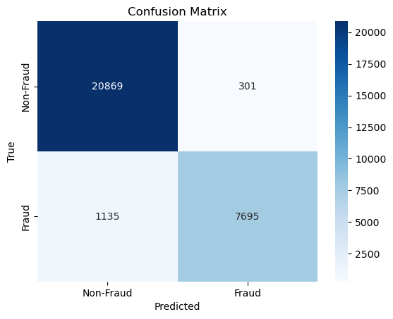

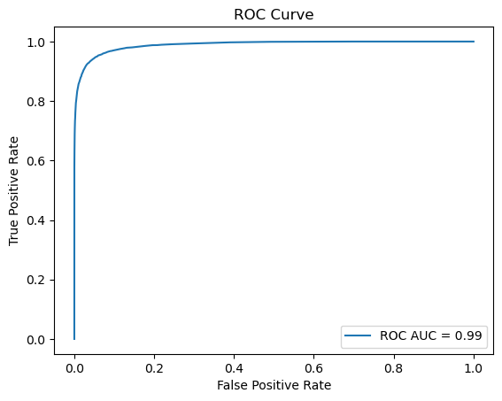

```python
# Train a Random Forest model
rf_model = RandomForestClassifier(
    max_depth=None,
    max_features='sqrt',
    min_samples_split=2,
    n_estimators=200,
    random_state=42,
    class_weight='balanced'
)
rf_model.fit(X_train, y_train)

# Predict on the test set
y_pred = rf_model.predict(X_test)
y_proba = rf_model.predict_proba(X_test)[:, 1]  # Probabilities for ROC

# Calculate metrics
accuracy = accuracy_score(y_test, y_pred)
precision = precision_score(y_test, y_pred, average='binary', pos_label=1)
recall = recall_score(y_test, y_pred, average='binary', pos_label=1)
f1 = f1_score(y_test, y_pred, average='binary', pos_label=1)

# Print the results
print("Metrics")
print(f'Accuracy: {accuracy:.2f}')
print(f'Precision: {precision:.2f}')
print(f'Recall: {recall:.2f}')
print(f'F1 Score: {f1:.2f}')

# Classification Report
print("\nClassification Report:")
# Classification Report
print(classification_report(y_test, y_pred))

# Confusion Matrix
cm = confusion_matrix(y_test, y_pred)
sns.heatmap(cm, annot=True, cmap='Blues', fmt='g', xticklabels=['Non-Fraud', 'Fraud'], yticklabels=['Non-Fraud', 'Fraud'])
plt.xlabel('Predicted')
plt.ylabel('True')
plt.title('Confusion Matrix')
plt.show()

# ROC Curve
fpr, tpr, _ = roc_curve(y_test, y_proba)
roc_auc = auc(fpr, tpr)

plt.plot(fpr, tpr, label=f'ROC AUC = {roc_auc:.2f}')
plt.xlabel('False Positive Rate')
plt.ylabel('True Positive Rate')
plt.title('ROC Curve')
plt.legend()
plt.show()

# End time
end_time = time.time()
# Calculate and print the time taken
elapsed_time = end_time - start_time

results["Experiment3"]["Train Time"] = str(round(elapsed_time, 2)) + ' seconds'
results["Experiment3"]["Accuracy"] = accuracy
results["Experiment3"]["Precision"] = precision
results["Experiment3"]["Recall"] = recall
results["Experiment3"]["F1-Score"] = f1
results["Experiment3"]["Best Parameters"] = str(grid_search.best_params_)
```

### XGBClassifier

```python
results["Experiment4"] = {}
results["Experiment4"]["Model"] = "XGBClassifier"

# Start time
start_time = time.time()

# Split the data
X = sampled_rf.drop(columns=['Is Fraud?'])
y = sampled_rf['Is Fraud?']
X['card_id'] = X['card_id'].astype('category')

X_train, X_test, y_train, y_test = train_test_split(X, y, test_size=0.3, random_state=42)

# Define the parameter grid
param_grid = {
    'n_estimators': [100, 200],  # Number of trees
    'max_depth': [3, 5, 7],      # Tree depth
    'learning_rate': [0.01, 0.1, 0.2],  # Step size shrinkage
    'subsample': [0.8, 1.0],     # Fraction of samples used
    'colsample_bytree': [0.8, 1.0],  # Fraction of features used
    'gamma': [0, 0.1, 0.2],      # Regularization term
}

# Initialize XGBClassifier
xgb = XGBClassifier(random_state=42, eval_metric='logloss', enable_categorical=True)

# Perform GridSearchCV
grid_search = GridSearchCV(
    estimator=xgb,
    param_grid=param_grid,
    scoring='f1',   # Optimize for F1 Score
    cv=3,           # 3-fold cross-validation
    verbose=0,      # Print progress
    n_jobs=-1       # Use all available CPU cores
)

# Fit the model
grid_search.fit(X_train, y_train)

# Print best parameters
print("Best parameters:", grid_search.best_params_)
```

```
Best parameters: {'colsample_bytree': 0.8, 'gamma': 0.1, 'learning_rate': 0.2, 'max_depth': 7, 'n_estimators': 200, 'subsample': 1.0}
```

```
Metrics:
Accuracy: 0.97
Precision: 0.97
Recall: 0.94
F1 Score: 0.96

Classification Report:
              precision    recall  f1-score   support

           0       0.98      0.99      0.98     21170
           1       0.97      0.94      0.96      8830

    accuracy                           0.97     30000
   macro avg       0.97      0.96      0.97     30000
weighted avg       0.97      0.97      0.97     30000
```

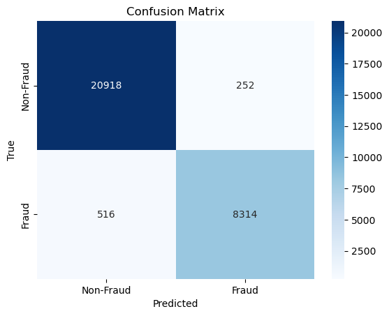

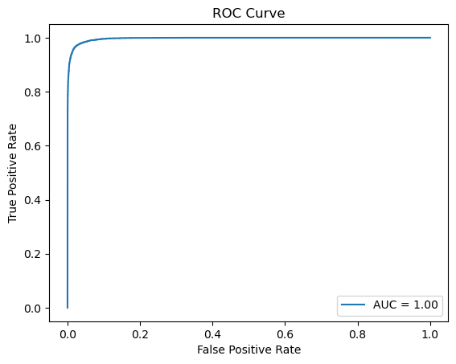

```python
# Evaluate the best model
best_xgb = grid_search.best_estimator_
y_pred = best_xgb.predict(X_test)

# Metrics Calculation
accuracy = accuracy_score(y_test, y_pred)
precision = precision_score(y_test, y_pred)
recall = recall_score(y_test, y_pred)
f1 = f1_score(y_test, y_pred)

# Print Metrics
print("\nMetrics:")
print(f'Accuracy: {accuracy:.2f}')
print(f'Precision: {precision:.2f}')
print(f'Recall: {recall:.2f}')
print(f'F1 Score: {f1:.2f}')

# Print classification report
print("\nClassification Report:")
print(classification_report(y_test, y_pred))

# Confusion Matrix
cm = confusion_matrix(y_test, y_pred)
sns.heatmap(cm, annot=True, cmap='Blues', fmt='g', xticklabels=['Non-Fraud', 'Fraud'], yticklabels=['Non-Fraud', 'Fraud'])
plt.xlabel('Predicted')
plt.ylabel('True')
plt.title('Confusion Matrix')
plt.show()

# ROC Curve
y_pred_proba = best_xgb.predict_proba(X_test)[:, 1]
fpr, tpr, _ = roc_curve(y_test, y_pred_proba)
plt.plot(fpr, tpr, label=f'AUC = {auc(fpr, tpr):.2f}')
plt.xlabel('False Positive Rate')
plt.ylabel('True Positive Rate')
plt.title('ROC Curve')
plt.legend()
plt.show()

# End time
end_time = time.time()
# Calculate and print the time taken
elapsed_time = end_time - start_time

results["Experiment4"]["Train Time"] = str(round(elapsed_time, 2)) + ' seconds'
results["Experiment4"]["Accuracy"] = accuracy
results["Experiment4"]["Precision"] = precision
results["Experiment4"]["Recall"] = recall
results["Experiment4"]["F1-Score"] = f1
results["Experiment4"]["Best Parameters"] = str(grid_search.best_params_)
```

### Fraud Detection with Neural Network

```
Using device: cpu
Epoch [1/50], Loss: 0.3889
Epoch [2/50], Loss: 0.3141
Epoch [3/50], Loss: 0.2851
Epoch [4/50], Loss: 0.2643
Epoch [5/50], Loss: 0.2497
Epoch [6/50], Loss: 0.2382
Epoch [7/50], Loss: 0.2293
Epoch [8/50], Loss: 0.2223
Epoch [9/50], Loss: 0.2169
Epoch [10/50], Loss: 0.2115
Epoch [11/50], Loss: 0.2063
Epoch [12/50], Loss: 0.2008
Epoch [13/50], Loss: 0.1970
Epoch [14/50], Loss: 0.1923
Epoch [15/50], Loss: 0.1891
Epoch [16/50], Loss: 0.1876
Epoch [17/50], Loss: 0.1828
Epoch [18/50], Loss: 0.1805
Epoch [19/50], Loss: 0.1768
Epoch [20/50], Loss: 0.1749
Epoch [21/50], Loss: 0.1728
Epoch [22/50], Loss: 0.1686
Epoch [23/50], Loss: 0.1683
Epoch [24/50], Loss: 0.1650
Epoch [25/50], Loss: 0.1645
Epoch [26/50], Loss: 0.1629
Epoch [27/50], Loss: 0.1612
Epoch [28/50], Loss: 0.1588
Epoch [29/50], Loss: 0.1568
Epoch [30/50], Loss: 0.1573
Epoch [31/50], Loss: 0.1551
Epoch [32/50], Loss: 0.1528
Epoch [33/50], Loss: 0.1510
Epoch [34/50], Loss: 0.1515
Epoch [35/50], Loss: 0.1486
Epoch [36/50], Loss: 0.1487
Epoch [37/50], Loss: 0.1477
Epoch [38/50], Loss: 0.1461
Epoch [39/50], Loss: 0.1440
Epoch [40/50], Loss: 0.1430
Epoch [41/50], Loss: 0.1421
Epoch [42/50], Loss: 0.1407
Epoch [43/50], Loss: 0.1382
Epoch [44/50], Loss: 0.1384
Early stopping due to no improvement in F1 score.
```

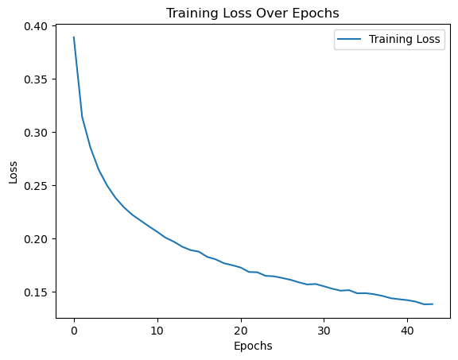

```
Metrics:
Accuracy: 0.93
Precision: 0.89
Recall: 0.85
F1 Score: 0.87

Classification Report:
              precision    recall  f1-score   support

         0.0       0.94      0.95      0.95     21170
         1.0       0.89      0.85      0.87      8830

    accuracy                           0.93     30000
   macro avg       0.91      0.90      0.91     30000
weighted avg       0.92      0.93      0.92     30000
```

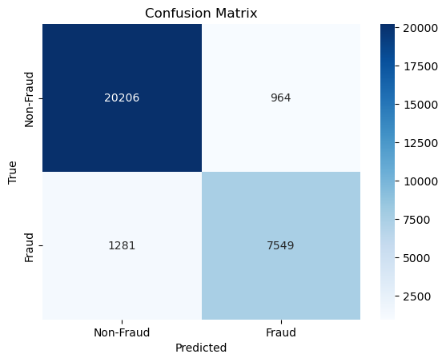

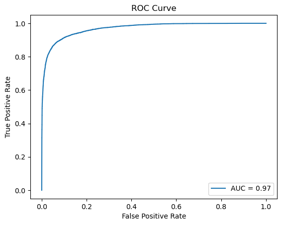

```python
results["Experiment5"] = {}
results["Experiment5"]["Model"] = "Neural Network"

# Start time
start_time = time.time()

# Check if GPU is available
device = torch.device("cuda" if torch.cuda.is_available() else "cpu")
print(f"Using device: {device}")

# Split the data
X = sampled_rf.drop(columns=['Is Fraud?'])
y = sampled_rf['Is Fraud?']

# Assume X and y are your preprocessed features and target variable
# Standardize the data
scaler = StandardScaler()
X_scaled = scaler.fit_transform(X)  # Assume X is your feature set

# Split the data into training and testing sets
X_train, X_test, y_train, y_test = train_test_split(X_scaled, y, test_size=0.3, random_state=42)

# Convert data to PyTorch tensors and move to GPU if available
X_train_tensor = torch.tensor(X_train, dtype=torch.float32).to(device)
X_test_tensor = torch.tensor(X_test, dtype=torch.float32).to(device)
y_train_tensor = torch.tensor(y_train.values, dtype=torch.float32).view(-1, 1).to(device)
y_test_tensor = torch.tensor(y_test.values, dtype=torch.float32).view(-1, 1).to(device)

# Create DataLoader for batch processing
train_dataset = TensorDataset(X_train_tensor, y_train_tensor)
test_dataset = TensorDataset(X_test_tensor, y_test_tensor)

batch_size = 64  # Batch size
train_loader = DataLoader(train_dataset, batch_size=batch_size, shuffle=True)
test_loader = DataLoader(test_dataset, batch_size=batch_size, shuffle=False)

# Define the Neural Network architecture
class FraudDetectionNN(nn.Module):
    def __init__(self):
        super(FraudDetectionNN, self).__init__()
        self.layer1 = nn.Linear(X_train.shape[1], 128)  # First layer with 128 neurons
        self.layer2 = nn.Linear(128, 64)  # Second layer with 64 neurons
        self.layer3 = nn.Linear(64, 32)  # Third layer with 32 neurons
        self.layer4 = nn.Linear(32, 1)  # Output layer with 1 neuron (binary classification)
        self.relu = nn.ReLU()  # ReLU activation function
        self.sigmoid = nn.Sigmoid()  # Sigmoid for output layer to output probabilities

    def forward(self, x):
        x = self.relu(self.layer1(x))
        x = self.relu(self.layer2(x))
        x = self.relu(self.layer3(x))
        x = self.sigmoid(self.layer4(x))
        return x

# Initialize the model, loss function, and optimizer
model = FraudDetectionNN().to(device)
criterion = nn.BCELoss()  # Binary Cross-Entropy Loss
optimizer = optim.Adam(model.parameters(), lr=0.001)  # Adam optimizer

# Early Stopping
best_f1 = 0.0
patience = 5
epochs_without_improvement = 0

# Train the model
num_epochs = 50
train_losses = []  # Store the loss during training

for epoch in range(num_epochs):
    model.train()  # Set the model to training mode
    running_loss = 0.0

    for inputs, labels in train_loader:
        optimizer.zero_grad()  # Zero the gradients
        outputs = model(inputs)  # Forward pass
        loss = criterion(outputs, labels)  # Calculate loss
        loss.backward()  # Backward pass
        optimizer.step()  # Update weights

        running_loss += loss.item()

    avg_train_loss = running_loss / len(train_loader)
    train_losses.append(avg_train_loss)

    print(f'Epoch [{epoch+1}/{num_epochs}], Loss: {avg_train_loss:.4f}')

    # Early stopping check (based on F1 score)
    model.eval()  # Set the model to evaluation mode
    y_pred_prob = model(X_test_tensor)
    y_pred = (y_pred_prob > 0.5).float()

    f1 = f1_score(y_test_tensor.cpu(), y_pred.cpu())
    if f1 > best_f1:
        best_f1 = f1
        epochs_without_improvement = 0
    else:
        epochs_without_improvement += 1

    if epochs_without_improvement >= patience:
        print("Early stopping due to no improvement in F1 score.")
        break

# Plot the training loss
plt.plot(train_losses, label="Training Loss")
plt.xlabel('Epochs')
plt.ylabel('Loss')
plt.title('Training Loss Over Epochs')
plt.legend()
plt.show()

# Evaluate the model
model.eval()  # Set the model to evaluation mode

# Make predictions on the test set
y_pred_prob = model(X_test_tensor)
y_pred = (y_pred_prob > 0.5).float()

# Calculate metrics
accuracy = accuracy_score(y_test_tensor.cpu(), y_pred.cpu())
precision = precision_score(y_test_tensor.cpu(), y_pred.cpu())
recall = recall_score(y_test_tensor.cpu(), y_pred.cpu())
f1 = f1_score(y_test_tensor.cpu(), y_pred.cpu())

# Print the metrics
print("Metrics:")
print(f'Accuracy: {accuracy:.2f}')
print(f'Precision: {precision:.2f}')
print(f'Recall: {recall:.2f}')
print(f'F1 Score: {f1:.2f}')

# Classification Report
print("\nClassification Report:")
print(classification_report(y_test_tensor.cpu(), y_pred.cpu()))

# Confusion Matrix
cm = confusion_matrix(y_test_tensor.cpu(), y_pred.cpu())
sns.heatmap(cm, annot=True, cmap='Blues', fmt='g', xticklabels=['Non-Fraud', 'Fraud'], yticklabels=['Non-Fraud', 'Fraud'])
plt.xlabel('Predicted')
plt.ylabel('True')
plt.title('Confusion Matrix')
plt.show()

# ROC Curve
fpr, tpr, _ = roc_curve(y_test_tensor.cpu(), y_pred_prob.detach().cpu().numpy())
plt.plot(fpr, tpr, label=f'AUC = {auc(fpr, tpr):.2f}')
plt.xlabel('False Positive Rate')
plt.ylabel('True Positive Rate')
plt.title('ROC Curve')
plt.legend()
plt.show()

# End time
end_time = time.time()
# Calculate and print the time taken
elapsed_time = end_time - start_time

results["Experiment5"]["Train Time"] = str(round(elapsed_time, 2)) + ' seconds'
results["Experiment5"]["Accuracy"] = accuracy
results["Experiment5"]["Precision"] = precision
results["Experiment5"]["Recall"] = recall
results["Experiment5"]["F1-Score"] = f1
results["Experiment5"]["Best Parameters"] = str("{'epochs': 50, 'optimizer': 'adam', 'lr': 0.001, 'batch_size': 64}")
```

### Fraud Detection with GNN

```python
sampled_rf.columns
```

```
Index(['Year', 'Month', 'Day', 'Amount', 'Use Chip', 'Merchant Name',
       'Merchant City', 'MCC', 'Errors?', 'Is Fraud?', 'card_id', 'Hour',
       'Minute', 'Day of Week'],
      dtype='object')
```

```python
# Create an empty graph
G = nx.MultiGraph()

# Add nodes to the graph for each unique card_id, merchant_name
G.add_nodes_from(sampled_rf["card_id"].unique(), type='card_id')
G.add_nodes_from(sampled_rf["Merchant Name"].unique(), type='merchant_name')
```

```python
# Add edges and properties to the edges
for _, row in sampled_rf.iterrows():
    # Create a variable for each properties for each edge
        year = row["Year"],
        month = row["Month"],
        day = row["Day"],
        amount = row["Amount"],
        use_chip =  row["Use Chip"],
        merchant_city = row["Merchant City"],
        mcc = row['MCC'],
        errors =  row["Errors?"],
        hour = row["Hour"],
        minute =row["Minute"],
        dow=row["Day of Week"]

        G.add_edge(row['card_id'], row['Merchant Name'], year = year , month = month , day = day ,
              hour = hour , minute = minute , amount = amount , use_chip = use_chip ,
              merchant_city = merchant_city , errors = errors , mcc = mcc, dow=dow)
```

```python
# Get the number of nodes and edges in the graph
num_nodes = G.number_of_nodes()
num_edges = G.number_of_edges()

# Print the number of nodes and edges
print("Number of nodes:", num_nodes)
print("Number of edges:", num_edges)
```

```
Number of nodes: 16336
Number of edges: 100000
```

```python
# Convert the graph to an adjacency matrix
adj_matrix = nx.adjacency_matrix(G).todense()
```

```python
# Get a small sample of the nodes in the graph
sample_nodes = list(G.nodes())[:10]

# Retrieve the properties of the sample nodes
node_properties = nx.get_node_attributes(G, 'type')

# Print the properties of the sample nodes
for node in sample_nodes:
    print(f"Node: {node}, Properties: {node_properties[node]}")
```

```
Node: 752_2, Properties: card_id
Node: 1930_1, Properties: card_id
Node: 1330_2, Properties: card_id
Node: 1110_0, Properties: card_id
Node: 486_4, Properties: card_id
Node: 935_0, Properties: card_id
Node: 1141_0, Properties: card_id
Node: 1911_2, Properties: card_id
Node: 343_0, Properties: card_id
Node: 1703_1, Properties: card_id
```

```python
sample_size = 5
for i, edge in enumerate(G.edges()):
    print(G.get_edge_data(*edge))
    if i >= sample_size - 1:
        break
```

```
{0: {'year': (2014,), 'month': (11,), 'day': (3,), 'hour': (7,), 'minute': (25,), 'amount': (5.69,), 'use_chip': (2,), 'merchant_city': (11613,), 'errors': (22,), 'mcc': (5541,), 'dow': 1}}
{0: {'year': (2014,), 'month': (8,), 'day': (1,), 'hour': (7,), 'minute': (19,), 'amount': (5.61,), 'use_chip': (2,), 'merchant_city': (11613,), 'errors': (22,), 'mcc': (5814,), 'dow': 0}}
{0: {'year': (2015,), 'month': (11,), 'day': (27,), 'hour': (16,), 'minute': (20,), 'amount': (46.34,), 'use_chip': (0,), 'merchant_city': (11613,), 'errors': (22,), 'mcc': (5411,), 'dow': 0}}
{0: {'year': (2014,), 'month': (6,), 'day': (12,), 'hour': (19,), 'minute': (28,), 'amount': (64.23,), 'use_chip': (2,), 'merchant_city': (460,), 'errors': (22,), 'mcc': (7995,), 'dow': 4}}
{0: {'year': (2010,), 'month': (4,), 'day': (25,), 'hour': (16,), 'minute': (33,), 'amount': (21.21,), 'use_chip': (2,), 'merchant_city': (10632,), 'errors': (22,), 'mcc': (4121,), 'dow': 3}, 1: {'year': (2011,), 'month': (4,), 'day': (23,), 'hour': (16,), 'minute': (55,), 'amount': (30.22,), 'use_c…
```

```python
# Retrieve the properties errors of all the edges
edge_properties = nx.get_edge_attributes(G, 'errors')

# Count the number of edges by property value
edge_count_by_property = Counter(edge_properties.values())

# Print the count of edges by property value
for property_value, count in edge_count_by_property.items():
    print(f"Property value: {property_value}, Count: {count}")
```

```
Property value: (22,), Count: 97574
Property value: (0,), Count: 306
Property value: (14,), Count: 448
Property value: (23,), Count: 213
Property value: (20,), Count: 1133
Property value: (10,), Count: 151
Property value: (3,), Count: 147
Property value: (15,), Count: 7
Property value: (11,), Count: 2
Property value: (1,), Count: 4
Property value: (13,), Count: 2
Property value: (8,), Count: 2
Property value: (2,), Count: 1
Property value: (12,), Count: 1
Property value: (21,), Count: 3
Property value: (17,), Count: 5
Property value: (16,), Count: 1
```

```python
# Prepare the data for input into the model
edge_list = list(G.edges(data=True))
```

```python
class ImprovedFraudGNN(nn.Module):
    def __init__(self, input_dim, hidden_dim):
        super(ImprovedFraudGNN, self).__init__()
        self.fc1 = nn.Linear(input_dim, hidden_dim)
        self.fc2 = nn.Linear(hidden_dim, hidden_dim)
        self.fc3 = nn.Linear(hidden_dim, hidden_dim // 2)
        self.fc4 = nn.Linear(hidden_dim // 2, 1)

        self.dropout = nn.Dropout(0.5)  # Prevent overfitting
        self.batch_norm1 = nn.BatchNorm1d(hidden_dim)
        self.batch_norm2 = nn.BatchNorm1d(hidden_dim)
        self.batch_norm3 = nn.BatchNorm1d(hidden_dim // 2)

    def forward(self, x):
        x = F.relu(self.batch_norm1(self.fc1(x)))
        x = self.dropout(x)
        x = F.relu(self.batch_norm2(self.fc2(x)))
        x = self.dropout(x)
        x = F.relu(self.batch_norm3(self.fc3(x)))
        x = self.fc4(x)
        return x

# Prepare the data for input into the model
edge_list = list(G.edges(data=True))
x = []
for edge in edge_list:
    edge_values = list(edge[2].values())
    edge_values = [float(i[0]) if type(i) == tuple and type(i[0]) == str else i[0] if type(i) == tuple else i for i in edge_values]
    x.append(edge_values)
x = torch.tensor(x, dtype=torch.float)
```

```python
target = torch.tensor(sampled_rf['Is Fraud?'].values, dtype=torch.float)
```

```python
x_train, x_valid, y_train, y_valid =  train_test_split(x, target, test_size=0.2, stratify=target)
x_valid, x_test, y_valid, y_test =  train_test_split(x_valid, y_valid, test_size=0.5, stratify=y_valid)
```

```python
# Define the model
input_dim = len(x[0])
print(input_dim)
hidden_dim = 128
model = ImprovedFraudGNN(input_dim, hidden_dim)
num_epochs = 300

# Define the loss function and optimizer
criterion = nn.BCEWithLogitsLoss()
optimizer = torch.optim.Adam(model.parameters(), lr=0.001)
```

```
11
```

```python
seed_val = 42
random.seed(seed_val)
np.random.seed(seed_val)
torch.manual_seed(seed_val)
torch.cuda.manual_seed_all(seed_val)
```

```python
results["Experiment6"] = {}
results["Experiment6"]["Model"] = "Graph Neural Network"

# Start time
start_time = time.time()

train_losses = []
val_losses = []

# Ensure y_train is of shape (batch_size, 1)
y_train = y_train.view(-1, 1)
y_valid = y_valid.view(-1, 1)
# Train the model
for i in range(num_epochs):
    # Forward pass
    output = model(x_train)
    # Compute the training loss
    loss = criterion(output, y_train)

    # Compute accuracy for training set
    predictions = torch.sigmoid(output)
    predicted_labels = (predictions > 0.4).float()
    accuracy = torch.mean((predicted_labels == y_train).float())

    if i % 20 == 0:
        print(f'Epoch: {i}, Train Loss: {loss.item()}, Train Accuracy: {accuracy.item()}')

        # Validation forward pass
        val_output = model(x_valid)
        val_loss = criterion(val_output, y_valid)
        val_losses.append(val_loss.item())

    # Zero the gradients
    optimizer.zero_grad()
    # Perform backpropagation
    loss.backward()
    # Update the parameters
    optimizer.step()

    train_losses.append(loss.item())
```

```
Epoch: 0, Train Loss: 0.7493125796318054, Train Accuracy: 0.31360000371932983
Epoch: 20, Train Loss: 0.6319715976715088, Train Accuracy: 0.5354375243186951
Epoch: 40, Train Loss: 0.6113961338996887, Train Accuracy: 0.6998999714851379
Epoch: 60, Train Loss: 0.610216498374939, Train Accuracy: 0.7022749781608582
Epoch: 80, Train Loss: 0.6094532012939453, Train Accuracy: 0.7023375034332275
Epoch: 100, Train Loss: 0.609413743019104, Train Accuracy: 0.7022749781608582
Epoch: 120, Train Loss: 0.6091274619102478, Train Accuracy: 0.7024000287055969
Epoch: 140, Train Loss: 0.6090623736381531, Train Accuracy: 0.7023875117301941
Epoch: 160, Train Loss: 0.6089781522750854, Train Accuracy: 0.7023749947547913
Epoch: 180, Train Loss: 0.6091009378433228, Train Accuracy: 0.7023875117301941
Epoch: 200, Train Loss: 0.6089909672737122, Train Accuracy: 0.7024000287055969
Epoch: 220, Train Loss: 0.6089844703674316, Train Accuracy: 0.7024375200271606
Epoch: 240, Train Loss: 0.608909547328949, Train Accuracy: 0.7024375200271606
Epoch: 260, Train Loss: 0.6089195609092712, Train Accuracy: 0.7023875117301941
Epoch: 280, Train Loss: 0.608853816986084, Train Accuracy: 0.7024250030517578
```

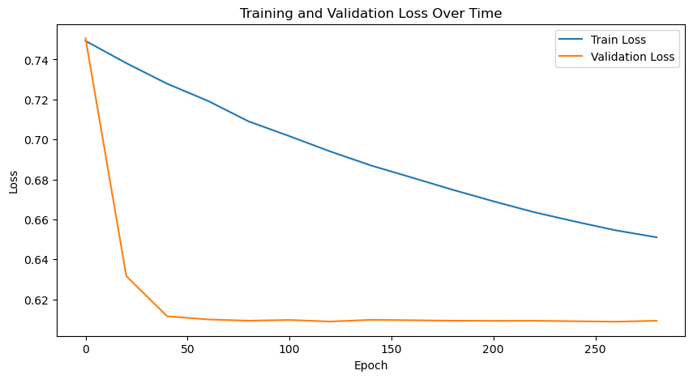

```python
plt.figure(figsize=(10, 5))
epochs_to_plot = range(0, num_epochs, 20)
plt.plot(epochs_to_plot, train_losses[:len(epochs_to_plot)], label='Train Loss')
plt.plot(epochs_to_plot, val_losses, label='Validation Loss')
plt.xlabel('Epoch')
plt.ylabel('Loss')
plt.title('Training and Validation Loss Over Time')
plt.legend()
plt.show()
```

```
Metrics:
Accuracy: 0.7025
Precision: 0.7025
Recall: 1.0000
F1-score: 0.8253

Classification Report:
              precision    recall  f1-score   support

         0.0       0.70      1.00      0.83      7025
         1.0       0.00      0.00      0.00      2975

    accuracy                           0.70     10000
   macro avg       0.35      0.50      0.41     10000
weighted avg       0.49      0.70      0.58     10000
```

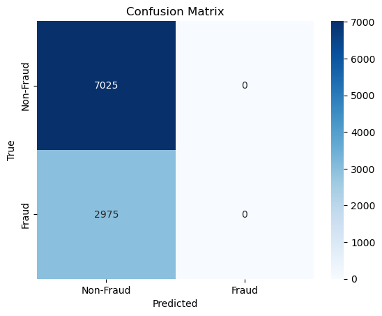

```python
# Set the model to evaluation mode
model.eval()

# Make predictions on the test set
with torch.no_grad():
    test_output = model(x_test)  # raw logits, no sigmoid here
    test_predictions = torch.sigmoid(test_output)  # Apply sigmoid to get probabilities
    predicted_labels = (test_predictions > 0.4).float()

# Calculate metrics
accuracy = torch.mean((predicted_labels == y_test).float()).item()

# Precision, Recall, F1-score
precision, recall, f1, _ = precision_recall_fscore_support(y_test.cpu(), predicted_labels.cpu())

# Print the metrics
print("Metrics:")
print(f'Accuracy: {accuracy:.4f}')
print(f'Precision: {precision[0]:.4f}')
print(f'Recall: {recall[0]:.4f}')
print(f'F1-score: {f1[0]:.4f}')

print("\nClassification Report:")
print(classification_report(y_test.cpu(), predicted_labels.cpu()))


# Confusion Matrix
cm = confusion_matrix(y_test.cpu(), predicted_labels.cpu())
sns.heatmap(cm, annot=True, cmap='Blues', fmt='g', xticklabels=['Non-Fraud', 'Fraud'], yticklabels=['Non-Fraud', 'Fraud'])
plt.xlabel('Predicted')
plt.ylabel('True')
plt.title('Confusion Matrix')
plt.show()

# End time
end_time = time.time()
# Calculate and print the time taken
elapsed_time = end_time - start_time

results["Experiment6"]["Train Time"] = str(round(elapsed_time, 2)) + ' seconds'
results["Experiment6"]["Accuracy"] = accuracy
results["Experiment6"]["Precision"] = precision[0]
results["Experiment6"]["Recall"] = recall[0]
results["Experiment6"]["F1-Score"] = f1[0]
results["Experiment6"]["Best Parameters"] = str("{'epochs': 300, 'optimizer': 'adam', 'lr': 0.001, 'hidden_dimension': 128}")
```

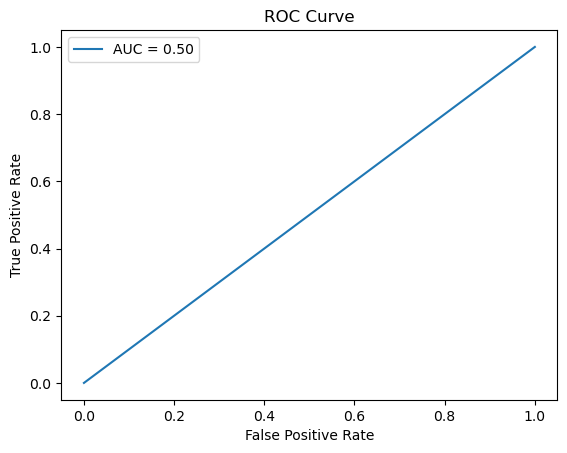

```python
# ROC Curve
fpr, tpr, _ = roc_curve(y_test.cpu(), predicted_labels.detach().cpu().numpy())
plt.plot(fpr, tpr, label=f'AUC = {auc(fpr, tpr):.2f}')
plt.xlabel('False Positive Rate')
plt.ylabel('True Positive Rate')
plt.title('ROC Curve')
plt.legend()
plt.show()
```

### Result

```python
# Convert the dictionary to a DataFrame
from IPython.display import display, HTML
display(HTML("<style>.container { width:80% !important; }</style>"))
resultDf = pd.DataFrame(results).T
```

```python
display(HTML(resultDf.to_html(escape=False)))
```

|  | Model | Train Time | Accuracy | Precision | Recall | F1-Score | Best Parameters |
| --- | --- | --- | --- | --- | --- | --- | --- |
| Experiment1 | Logistic Regression | 5.28 seconds | 0.6919 | 0.483723 | 0.695017 | 0.570433 | {'C': 0.1, 'max_iter': 100, 'penalty': 'l1', 'solver': 'liblinear'} |
| Experiment2 | Support Vector Machine | 4203.29 seconds | 0.859167 | 0.733875 | 0.818233 | 0.773762 | {'C': 1, 'gamma': 0.1, 'kernel': 'rbf'} |
| Experiment3 | Random Forest | 282.75 seconds | 0.952133 | 0.962356 | 0.871461 | 0.914656 | {'max_depth': None, 'max_features': 'sqrt', 'min_samples_split': 2, 'n_estimators': 200} |
| Experiment4 | XGBClassifier | 162.54 seconds | 0.9744 | 0.970581 | 0.941563 | 0.955852 | {'colsample_bytree': 0.8, 'gamma': 0.1, 'learning_rate': 0.2, 'max_depth': 7, 'n_estimators': 200, 'subsample': 1.0} |
| Experiment5 | Neural Network | 109.45 seconds | 0.925167 | 0.886761 | 0.854926 | 0.870553 | {'epochs': 50, 'optimizer': 'adam', 'lr': 0.001, 'batch_size': 64} |
| Experiment6 | Graph Neural Network | 250.0 seconds | 0.7025 | 0.7025 | 1.0 | 0.825257 | {'epochs': 300, 'optimizer': 'adam', 'lr': 0.001, 'hidden_dimension': 128} |

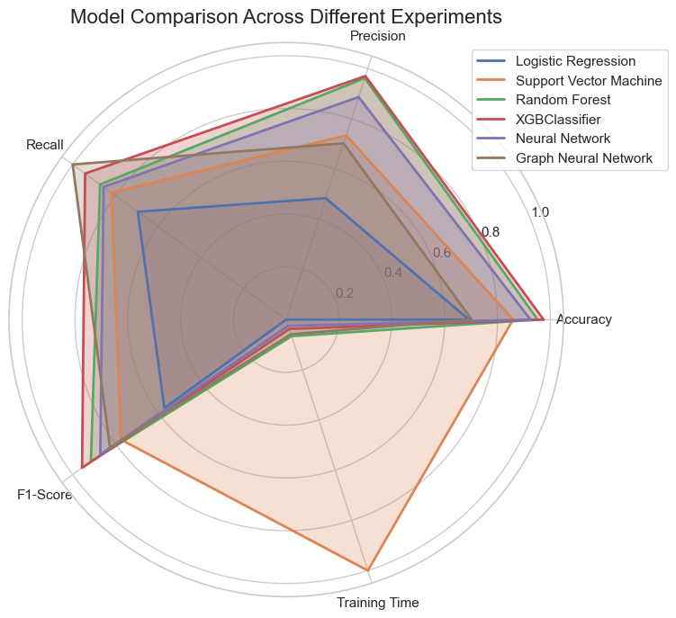

```python
# Extracting metrics and model names
experiments = [results[exp]['Model'] for exp in results.keys()]
accuracy = [results[exp]['Accuracy'] for exp in results.keys()]
precision = [results[exp]['Precision'] for exp in results.keys()]
recall = [results[exp]['Recall'] for exp in results.keys()]
f1_score = [results[exp]['F1-Score'] for exp in results.keys()]

# Extract training times as numeric values
train_time = [float(results[exp]['Train Time'].split()[0]) for exp in results.keys()]

# Normalize training time to bring it to the same scale as other metrics (0-1)
max_train_time = max(train_time)
min_train_time = min(train_time)
normalized_train_time = [(t - min_train_time) / (max_train_time - min_train_time) for t in train_time]

# Metrics
labels = ['Accuracy', 'Precision', 'Recall', 'F1-Score', 'Training Time']
metrics = [accuracy, precision, recall, f1_score, normalized_train_time]

# Number of experiments
num_experiments = len(experiments)

# Set up radar chart
angles = np.linspace(0, 2 * np.pi, len(labels), endpoint=False).tolist()
angles += angles[:1]  # Ensure closing of the radar chart

# Create the plot
fig, ax = plt.subplots(figsize=(8, 8), subplot_kw=dict(polar=True))

# Plot each experiment
for i, experiment in enumerate(experiments):
    data = [accuracy[i], precision[i], recall[i], f1_score[i], normalized_train_time[i]]
    data += data[:1]  # Close the loop
    ax.plot(angles, data, label=experiment, linewidth=2, linestyle='solid')
    ax.fill(angles, data, alpha=0.25)

# Set the labels for each axis
ax.set_xticks(angles[:-1])
ax.set_xticklabels(labels)

# Add a legend
ax.legend(loc='upper right', bbox_to_anchor=(1.2, 1))

# Title
plt.title('Model Comparison Across Different Experiments', size=16)

# Display the plot
plt.show()
```